# Daily exercises 11-12

Exploratory Data Analysis and Linear Regression in R

Author

Yazeed Aljohani

Published

March 12, 2025

## **Part 1: Normality Testing**

1. **Load the airquality dataset in R. What does this dataset represent? Explore its structure using functions like `str()` and `summary()`.**

```r
data("airquality")
str(airquality)
```

```
'data.frame':   153 obs. of  6 variables:
 $ Ozone  : int  41 36 12 18 NA 28 23 19 8 NA ...
 $ Solar.R: int  190 118 149 313 NA NA 299 99 19 194 ...
 $ Wind   : num  7.4 8 12.6 11.5 14.3 14.9 8.6 13.8 20.1 8.6 ...
 $ Temp   : int  67 72 74 62 56 66 65 59 61 69 ...
 $ Month  : int  5 5 5 5 5 5 5 5 5 5 ...
 $ Day    : int  1 2 3 4 5 6 7 8 9 10 ...
```

```r
summary(airquality)
```

```
     Ozone           Solar.R           Wind             Temp
 Min.   :  1.00   Min.   :  7.0   Min.   : 1.700   Min.   :56.00
 1st Qu.: 18.00   1st Qu.:115.8   1st Qu.: 7.400   1st Qu.:72.00
 Median : 31.50   Median :205.0   Median : 9.700   Median :79.00
 Mean   : 42.13   Mean   :185.9   Mean   : 9.958   Mean   :77.88
 3rd Qu.: 63.25   3rd Qu.:258.8   3rd Qu.:11.500   3rd Qu.:85.00
 Max.   :168.00   Max.   :334.0   Max.   :20.700   Max.   :97.00
 NA's   :37       NA's   :7
     Month            Day
 Min.   :5.000   Min.   : 1.0
 1st Qu.:6.000   1st Qu.: 8.0
 Median :7.000   Median :16.0
 Mean   :6.993   Mean   :15.8
 3rd Qu.:8.000   3rd Qu.:23.0
 Max.   :9.000   Max.   :31.0
```

2. **Perform a Shapiro-Wilk normality test on the following variables: `Ozone`, `Temp`, `Solar.R`, and `Wind.`**

```r
#Shapiro-Wilk Normality Test
shapiro.test(airquality$Ozone)
```

```
    Shapiro-Wilk normality test

data:  airquality$Ozone
W = 0.87867, p-value = 2.79e-08
```

```r
shapiro.test(airquality$Temp)
```

```
    Shapiro-Wilk normality test

data:  airquality$Temp
W = 0.97617, p-value = 0.009319
```

```r
shapiro.test(airquality$Solar.R)
```

```
    Shapiro-Wilk normality test

data:  airquality$Solar.R
W = 0.94183, p-value = 9.492e-06
```

```r
shapiro.test(airquality$Wind)
```

```
    Shapiro-Wilk normality test

data:  airquality$Wind
W = 0.98575, p-value = 0.1178
```

3. **What is the purpose of the Shapiro-Wilk test?**

   The Shapiro-Wilk test checks whether a dataset follows a normal distribution.
4. **What are the null and alternative hypotheses for this test?**
   - **Null Hypothesis (H₀):** The data is normally distributed.
   - **Alternative Hypothesis (H₁):** The data is not normally distributed.

     If p-value < 0.05, we reject H₀, meaning the data is likely not normally distributed.

     If p-value ≥ 0.05, we fail to reject H₀, meaning the data may be normally distributed.
     5. **Interpret the p-values. Are these variables normally distributed?**

     Test Results Interpretation

     | **Variable** | **W Statistic** | **p-value** | **Normality Conclusion** |
     | --- | --- | --- | --- |
     | Ozone | 0.87867 | 2.79e-08 | Not Normal (p < 0.05) |
     | Temp | 0.97617 | 0.009319 | Not Normal (p < 0.05) |
     | Solar.R | 0.94183 | 9.49e-06 | Not Normal (p < 0.05) |
     | Wind | 0.98575 | 0.1178 | Possibly Normal (p > 0.05) |

## **Part 2: Data Transformation and Feature Engineering**

6. **Create a new column with `case_when` tranlating the Months into four seasons (Winter (Nov, Dec, Jan), Spring (Feb, Mar, Apr), Summer (May, Jun, Jul), and Fall (Aug, Sep, Oct)).**

```r
# Creating a Season Column
airquality <- airquality %>%
  mutate(Season = case_when(
    Month %in% c(11, 12, 1) ~ "Winter",
    Month %in% c(2, 3, 4) ~ "Spring",
    Month %in% c(5, 6, 7) ~ "Summer",
    Month %in% c(8, 9, 10) ~ "Fall"
  ))
```

7. **Use `table` to figure out how many observations we have from each season.**

   ```r
   # Counting Observations per Season

   table(airquality$Season)
   ```

   ```
     Fall Summer
       61     92
   ```

## **Part 3: Data Preprocessing**

8. **Normalize the predictor variables (Temp, Solar.R, Wind, and Season) using a `recipe`**

   ```r
   # Normalizing Data
   recipe <- recipe(Ozone ~ Temp + Solar.R + Wind + Season, data = airquality) %>%
     step_normalize(all_numeric_predictors()) %>%
     step_impute_mean(all_numeric_predictors()) %>%
     step_dummy(all_nominal_predictors())
   ```

9. **What is the purpose of normalizing data?**

Normalizing data ensures that all variables contribute equally, preventing large-scale features from dominating models.

10. **What function can be used to impute missing values with the mean?**

    step_impute_mean() function.
11. **`prep` and `bake` the data to generate a processed dataset.**

    ```r
    # Preparing and Applying Recipe
    prepped_recipe <- prep(recipe, training = airquality)
    norm_data <- bake(prepped_recipe, new_data = airquality)
    head(norm_data)
    ```

    ```
    # A tibble: 6 × 5
        Temp   Solar.R   Wind Ozone Season_Summer
       <dbl>     <dbl>  <dbl> <int>         <dbl>
    1 -1.15   4.52e- 2 -0.726    41             1
    2 -0.621 -7.54e- 1 -0.556    36             1
    3 -0.410 -4.10e- 1  0.750    12             1
    4 -1.68   1.41e+ 0  0.438    18             1
    5 -2.31  -2.02e-17  1.23     NA             1
    6 -1.26  -2.02e-17  1.40     28             1
    ```

I got: Temp, Solar.R, and Wind are normalized, so their values are now scaled around zero. Ozone is still in its original form, and there’s one missing value (`NA`). The Season_Summer column is a dummy variable, meaning all these rows are from summer (`1`).

12. **Why is it necessary to both `prep()` and `bake()` the recipe?**

    I would say, `prep()` is like getting everything ready before cooking. it calculates things like the mean for scaling. `bake()` is actually applying those transformations to the data, just like cooking the meal.

## **Part 4: Building a Linear Regression Model**

13. **Fit a linear model using Ozone as the response variable and all other variables as predictors. Remeber that the `.` notation can we used to include all variables.**

```r
model <- lm(Ozone ~ ., data = norm_data)
summary(model)
```

```
Call:
lm(formula = Ozone ~ ., data = norm_data)

Residuals:
    Min      1Q  Median      3Q     Max
-39.591 -14.802  -2.437  10.510  99.531

Coefficients:
              Estimate Std. Error t value Pr(>|t|)
(Intercept)     39.816      2.970  13.405  < 2e-16 ***
Temp            16.375      2.477   6.612 1.38e-09 ***
Solar.R          4.973      2.158   2.305   0.0231 *
Wind           -10.952      2.282  -4.800 4.98e-06 ***
Season_Summer    3.988      4.197   0.950   0.3441
---
Signif. codes:  0 '***' 0.001 '**' 0.01 '*' 0.05 '.' 0.1 ' ' 1

Residual standard error: 21.33 on 111 degrees of freedom
  (37 observations deleted due to missingness)
Multiple R-squared:  0.5964,    Adjusted R-squared:  0.5819
F-statistic: 41.01 on 4 and 111 DF,  p-value: < 2.2e-16
```

13. **Interpret the model summary output (coefficients, R-squared, p-values) in plain language**

The model shows that temperature significantly increases Ozone levels, while wind reduces them. Solar radiation has a moderate effect, but season (Summer) is not significant. The model explains 60% of the Ozone variation, meaning other factors influence it. 37 rows were removed due to missing values, which could impact accuracy. The F-statistic confirms the model is strong, but large residuals suggest possible outliers. To improve, I may consider handling missing data and checking residual plots for better predictions.

## **Part 5: Model Diagnostics**

15. **Use `broom::augment` to suppliment the normalized `data.frame` with the fitted values and residuals.**

```r
# cleaning andExtracting Residuals and Predictions
clean_data <- na.omit(norm_data)  # Remove missing values first
predictions <- augment(model, clean_data)
```

16. **Extract the residuals and visualize their distribution as a histogram and qqplot.**
17. **Use `ggarange` to plot this as one image and interpret what you see in them.**

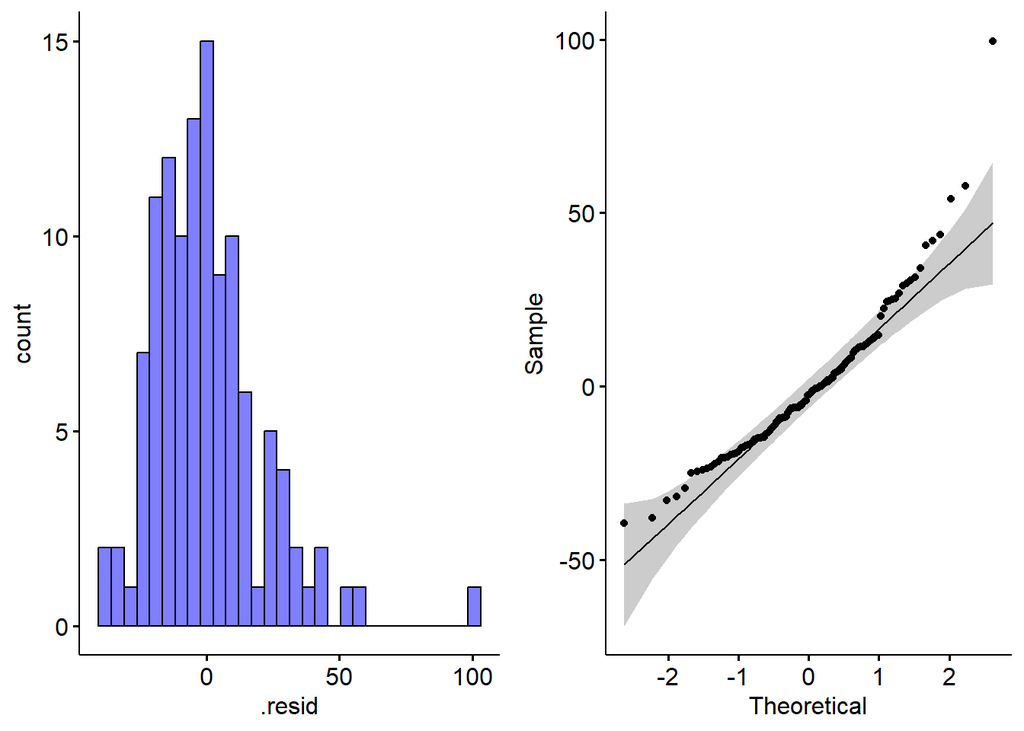

    ```r
    ### Histogram and QQ-Plot of Residuals
    p1 <- gghistogram(predictions, x = ".resid", fill = "blue")
    p2 <- ggqqplot(predictions$.resid)
    ggarrange(p1, p2, ncol = 2, nrow = 1)
    ```

The residual histogram is right-skewed, suggesting non-normal residuals and potential underprediction in some cases. The Q-Q plot shows deviation in the right tail, indicating outliers or heteroscedasticity. This suggests violations of regression assumptions, possibly affecting accuracy.

18. **Create a scatter plot of actual vs. predicted values using ggpubr**

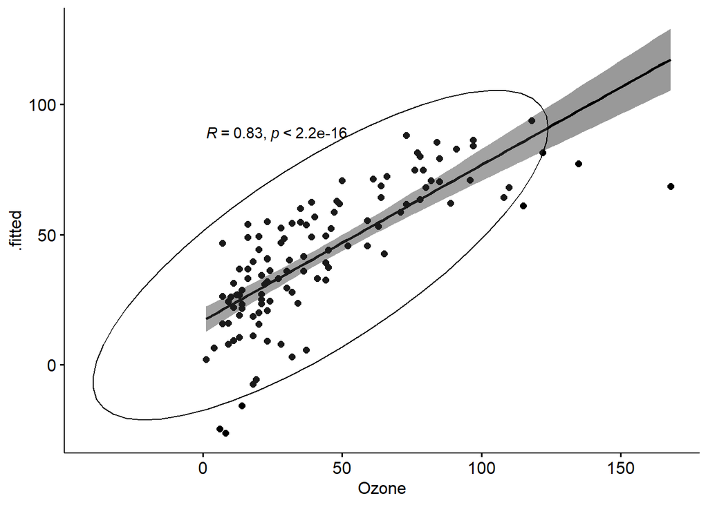

    ```r
    ggscatter(predictions, x = "Ozone", y = ".fitted",
              add = "reg.line", conf.int = TRUE,
              cor.coef = TRUE, cor.method = "spearman",
              ellipse = TRUE)
    ```

19. **How strong of a model do you think this is?**

    My model explains about 60% of the variation in Ozone levels, meaning there’s still 40% unaccounted for. Temperature and Wind strongly impact Ozone, while Solar Radiation has a smaller effect and Season doesn’t matter much. The residuals are skewed, suggesting outliers or assumption violations. To improve it, I could check for outliers, apply log transformations, or add more predictors like humidity. Overall, it’s a decent model but not perfect, I can definitely make it stronger!